# Project 2.

## Facial Emotion Recognition Dataset: Understanding Human Expressions

This project was completed by Irina Maruna and Lucas Chapelle for DAT 402.

For this project we are using a "Facial Emotion Recognition Image Dataset" originally published on Kaggle:  
https://www.kaggle.com/datasets/sujaykapadnis/emotion-recognition-dataset?resource=download

### Dataset Overview

This dataset contains images of human faces categorized into six distinct emotions:

- Happy
- Angry
- Sad
- Neutral
- Surprise
- Ahego (a nice expressive reaction)

### Data Source & Collection

The images were acquired through various methods:

- Social Media Scraping
- YouTube Frames
- Existing Datasets

### Objective

The aim of this project is to apply machine learning techniques to:

- Classify emotions
- Analyze trends and common misclassifications in emotion recognition models
- Evaluate different ML architectures, including deep learning methods like CNNs

## 📦 Setup: Installing and Importing Libraries

```python
## Install opencv-python
!pip install opencv-python
```

```python
# Check TensorFlow version (for compatibility)
!pip show tensorflow
```

```
Name: tensorflow
Version: 2.19.0
Summary: TensorFlow is an open source machine learning framework for everyone.
Home-page: https://www.tensorflow.org/
Author: Google Inc.
Author-email: packages@tensorflow.org
License: Apache 2.0
Location: C:\Users\apakh\anaconda3\Lib\site-packages
Requires: absl-py, astunparse, flatbuffers, gast, google-pasta, grpcio, h5py, keras, libclang, ml-dtypes, numpy, opt-einsum, packaging, protobuf, requests, setuptools, six, tensorboard, termcolor, typing-extensions, wrapt
Required-by:
```

```python
# Import Required Libraries for data processing, visualization, and modeling
import numpy as np              # for numerical operations
import pandas as pd             # for data handling (if needed later)
import cv2                      # for image processing
import os                       # for file and directory handling
import matplotlib.pyplot as plt # for data visualization
import tensorflow as tf         # for building and training CNN
from tensorflow.keras.preprocessing.image import ImageDataGenerator  # # for loading image data

# Set the correct path to your dataset

dataset_path = r"C:\Users\apakh\OneDrive\Desktop\dataset"
```

## **Exploratory Data Analysis (EDA)**

Before training models, it's important to understand the dataset through visualizations and descriptive statistics.

### 1. Number of Images per Emotion Category

We count how many images are available for each emotion to understand class balance and identify any imbalance that could affect model performance.

```python
from collections import defaultdict

# Create a dictionary to count the number of images per emotion category
image_counts = defaultdict(int)

# Loop through each emotion folder and count image files
for emotion in os.listdir(dataset_path):
    emotion_path = os.path.join(dataset_path, emotion)
    if os.path.isdir(emotion_path):
        image_counts[emotion] = len(os.listdir(emotion_path))

# Convert the counts into a DataFrame and sort by image count
image_counts_df = pd.DataFrame(list(image_counts.items()), columns=["Emotion", "Count"])
image_counts_df = image_counts_df.sort_values(by="Count", ascending=False)

# Display the result
print(image_counts_df)
```

```
    Emotion  Count
3   Neutral   4027
4       Sad   3934
2     Happy   3740
1     Angry   1313
5  Surprise   1234
0    Ahegao   1205
```

### 2.Image Size Distribution

*Before resizing images for modeling, it's helpful to explore their original dimensions. This analysis helps confirm whether images vary greatly in shape or resolution, and whether resizing (e.g., to 64×64) is appropriate.*

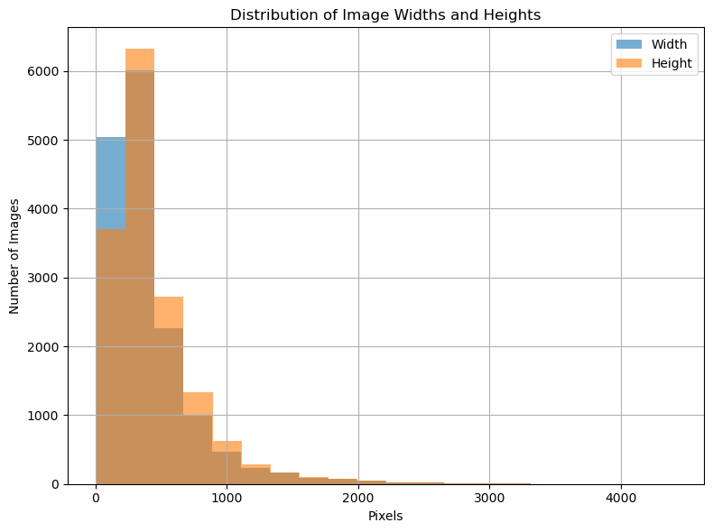

```python
from PIL import Image

image_sizes = []

# Loop through each emotion folder
for emotion in os.listdir(dataset_path):
    emotion_folder = os.path.join(dataset_path, emotion)
    if os.path.isdir(emotion_folder):
        for img_file in os.listdir(emotion_folder):
            img_path = os.path.join(emotion_folder, img_file)
            try:
                with Image.open(img_path) as img:
                    image_sizes.append(img.size)  # (width, height)
            except: # Skip corrupted or unreadable images
                pass

# Convert image sizes into a DataFrame
size_df = pd.DataFrame(image_sizes, columns=["Width", "Height"])

# Plot histogram of image widths and heights
plt.figure(figsize=(8, 6))
plt.hist(size_df["Width"], bins=20, alpha=0.6, label='Width')
plt.hist(size_df["Height"], bins=20, alpha=0.6, label='Height')
plt.xlabel("Pixels")
plt.ylabel("Number of Images")
plt.title("Distribution of Image Widths and Heights")
plt.legend()
plt.grid(True)
plt.tight_layout()
plt.show()
```

### Observation

*The majority of images have widths and heights under 500 pixels, but there is variation across the dataset. Resizing all images to a fixed size (e.g., 64×64) is necessary to standardize input for modeling and reduce computational complexity.*

### 3.Class Balance Visualization

*To better understand the distribution of emotion labels, we plot the number of images per category. Class imbalance can affect model learning — categories with fewer examples may be harder to classify correctly.*

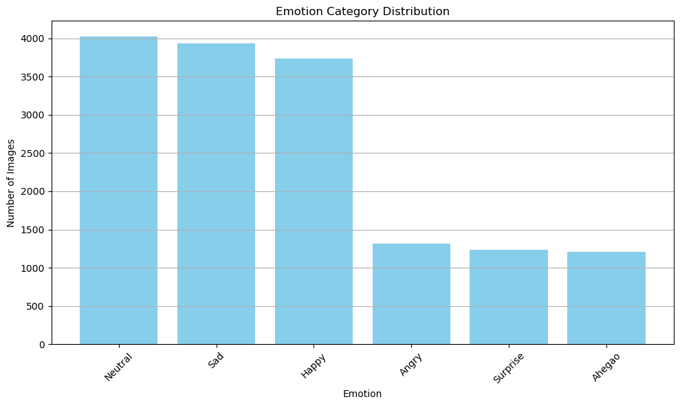

```python
# Bar plot showing how many images exist for each emotion category
plt.figure(figsize=(10, 6))
plt.bar(image_counts_df["Emotion"], image_counts_df["Count"], color='skyblue')
plt.xlabel("Emotion")
plt.ylabel("Number of Images")
plt.title("Emotion Category Distribution")
plt.xticks(rotation=45) # Rotate labels for readability
plt.grid(axis='y')      # Show horizontal grid lines
plt.tight_layout()
plt.show()
```

**Observation**

*This bar plot shows the distribution of image counts across emotion categories. We observe a significant class imbalance*:

- *'Neutral', 'Sad', and 'Happy' have many more examples,*
- *while 'Angry', 'Surprise', and 'Ahegao' are underrepresented.*

*This imbalance may impact the model's ability to classify minority emotions accurately.*

*To train and evaluate our model reliably, we divide the dataset into training and validation sets. We use TensorFlow’s `ImageDataGenerator` to handle both loading and preprocessing (like rescaling pixel values).*

```python
from tensorflow.keras.preprocessing.image import ImageDataGenerator

IMG_SIZE = (64, 64)
BATCH_SIZE = 32

# Create image data generator with normalization and validation split
datagen = ImageDataGenerator(rescale=1./255, validation_split=0.3)

# Load training data (70% of total data)
train_generator = datagen.flow_from_directory(
    dataset_path,
    target_size=IMG_SIZE,
    batch_size=BATCH_SIZE,
    class_mode='categorical',
    subset='training',
    shuffle=True
)

# Load validation data (30% of total data)
val_generator = datagen.flow_from_directory(
    dataset_path,
    target_size=IMG_SIZE,
    batch_size=BATCH_SIZE,
    class_mode='categorical',
    subset='validation',
    shuffle=True
)
```

```
Found 10819 images belonging to 6 classes.
Found 4634 images belonging to 6 classes.
```

### **Visualize Sample Images**

*To ensure images are loaded and labeled correctly, we preview a small batch of training images with their associated emotion labels.*

[figure not shown]

```python
# Get one batch
images, labels = next(train_generator)

# Class labels
class_names = list(train_generator.class_indices.keys())

# Smaller but still readable grid
plt.figure(figsize=(10, 10))
for i in range(9):
    plt.subplot(3, 3, i+1)
    plt.imshow(images[i], interpolation='nearest')  # crisp display
    plt.title(class_names[np.argmax(labels[i])], fontsize=12)
    plt.axis('off')
plt.suptitle("Sample Emotion Images", fontsize=16)
plt.tight_layout()
plt.subplots_adjust(top=0.92)
plt.show()
```

**Observation**

*These sample images confirm that the dataset is diverse and labeled correctly. We observe a mix of clear and low-quality images, which may influence model performance and generalization.*

### **Build a CNN Model**

*We now define a Convolutional Neural Network (CNN) to classify facial expressions. CNNs are effective for image tasks because they learn spatial patterns such as edges, shapes, and textures.*

```python
from tensorflow.keras.models import Sequential
from tensorflow.keras.layers import Conv2D, MaxPooling2D, Flatten, Dense, Dropout
from tensorflow.keras import Input

# Define a simple CNN model architecture
model = Sequential([
    Input(shape=(64, 64, 3)),                 # Input layer: 64x64 RGB images
    # First Convolutional Block
    Conv2D(32, (3, 3), activation='relu'),    # 32 filters, 3x3 kernel
    MaxPooling2D(2, 2),                       # # Downsample by 2x

    # Second Convolutional Block
    Conv2D(64, (3, 3), activation='relu'),    # 64 filters
    MaxPooling2D(2, 2),

    # Flatten and Dense Layers
    Flatten(),
    Dense(128, activation='relu'),            # Fully connected layer
    Dropout(0.5),                             # Prevent overfitting
    Dense(6, activation='softmax')            # Output layer (6 emotion classes)
])

# Compile the model
model.compile(optimizer='adam',
              loss='categorical_crossentropy',
              metrics=['accuracy'])

# Summary
model.summary()
```

```
Model: "sequential"
```

```
┏━━━━━━━━━━━━━━━━━━━━━━━━━━━━━━━━━━━━━━┳━━━━━━━━━━━━━━━━━━━━━━━━━━━━━┳━━━━━━━━━━━━━━━━━┓
┃ Layer (type)                         ┃ Output Shape                ┃         Param # ┃
┡━━━━━━━━━━━━━━━━━━━━━━━━━━━━━━━━━━━━━━╇━━━━━━━━━━━━━━━━━━━━━━━━━━━━━╇━━━━━━━━━━━━━━━━━┩
│ conv2d (Conv2D)                      │ (None, 62, 62, 32)          │             896 │
├──────────────────────────────────────┼─────────────────────────────┼─────────────────┤
│ max_pooling2d (MaxPooling2D)         │ (None, 31, 31, 32)          │               0 │
├──────────────────────────────────────┼─────────────────────────────┼─────────────────┤
│ conv2d_1 (Conv2D)                    │ (None, 29, 29, 64)          │          18,496 │
├──────────────────────────────────────┼─────────────────────────────┼─────────────────┤
│ max_pooling2d_1 (MaxPooling2D)       │ (None, 14, 14, 64)          │               0 │
├──────────────────────────────────────┼─────────────────────────────┼─────────────────┤
│ flatten (Flatten)                    │ (None, 12544)               │               0 │
├──────────────────────────────────────┼─────────────────────────────┼─────────────────┤
│ dense (Dense)                        │ (None, 128)                 │       1,605,760 │
├──────────────────────────────────────┼─────────────────────────────┼─────────────────┤
│ dropout (Dropout)                    │ (None, 128)                 │               0 │
├──────────────────────────────────────┼─────────────────────────────┼─────────────────┤
│ dense_1 (Dense)                      │ (None, 6)                   │             774 │
└──────────────────────────────────────┴─────────────────────────────┴─────────────────┘
```

```
 Total params: 1,625,926 (6.20 MB)
```

```
 Trainable params: 1,625,926 (6.20 MB)
```

```
 Non-trainable params: 0 (0.00 B)
```

**Observation**

*This table shows the structure of our CNN model. It includes two convolutional blocks followed by dense layers.*

- The model begins with two sets of Conv2D and MaxPooling2D layers. These layers help the model look at small parts of the image and learn shapes, lines, and patterns.
- The **Flatten** layer turns the 2D feature maps into a 1D vector.
- The **Dense (128)** layer is fully connected and learns more complex combinations of features.
- A **Dropout** layer is used to prevent overfitting.
- The final **Dense (6)** layer outputs the prediction probabilities for each of the 6 emotion categories.

The model has around **1.6 million trainable parameters**, which means it's powerful enough to learn from a rich dataset like ours but still efficient to train.

### **Train the Model**

```python
history = model.fit(
    train_generator,
    validation_data=val_generator,
    epochs=10
)
```

```
339/339 ━━━━━━━━━━━━━━━━━━━━ 223s 649ms/step - accuracy: 0.3177 - loss: 1.5843 - val_accuracy: 0.4959 - val_loss: 1.4545
339/339 ━━━━━━━━━━━━━━━━━━━━ 185s 547ms/step - accuracy: 0.4899 - loss: 1.2457 - val_accuracy: 0.5589 - val_loss: 1.2215
339/339 ━━━━━━━━━━━━━━━━━━━━ 192s 567ms/step - accuracy: 0.5543 - loss: 1.0856 - val_accuracy: 0.5814 - val_loss: 1.1829
339/339 ━━━━━━━━━━━━━━━━━━━━ 183s 540ms/step - accuracy: 0.5983 - loss: 0.9807 - val_accuracy: 0.5934 - val_loss: 1.1399
339/339 ━━━━━━━━━━━━━━━━━━━━ 184s 542ms/step - accuracy: 0.6387 - loss: 0.8865 - val_accuracy: 0.6224 - val_loss: 1.0900
339/339 ━━━━━━━━━━━━━━━━━━━━ 175s 517ms/step - accuracy: 0.6556 - loss: 0.8155 - val_accuracy: 0.6152 - val_loss: 1.1373
339/339 ━━━━━━━━━━━━━━━━━━━━ 193s 570ms/step - accuracy: 0.7018 - loss: 0.7231 - val_accuracy: 0.6260 - val_loss: 1.0981
339/339 ━━━━━━━━━━━━━━━━━━━━ 195s 576ms/step - accuracy: 0.7170 - loss: 0.6812 - val_accuracy: 0.6278 - val_loss: 1.1689
339/339 ━━━━━━━━━━━━━━━━━━━━ 197s 581ms/step - accuracy: 0.7604 - loss: 0.6101 - val_accuracy: 0.6211 - val_loss: 1.2839
339/339 ━━━━━━━━━━━━━━━━━━━━ 197s 580ms/step - accuracy: 0.7657 - loss: 0.5645 - val_accuracy: 0.6528 - val_loss: 1.1096
```

**Observation**

- Training accuracy increased from 32% to 76%, and the training loss dropped from 1.58 to 0.56, meaning the model learned better with each pass through the data.
- Validation accuracy also rose from 49% to 65%, indicating the model is generalizing fairly well to unseen data and not just memorizing the training set.

### 1. Plot Accuracy and Loss

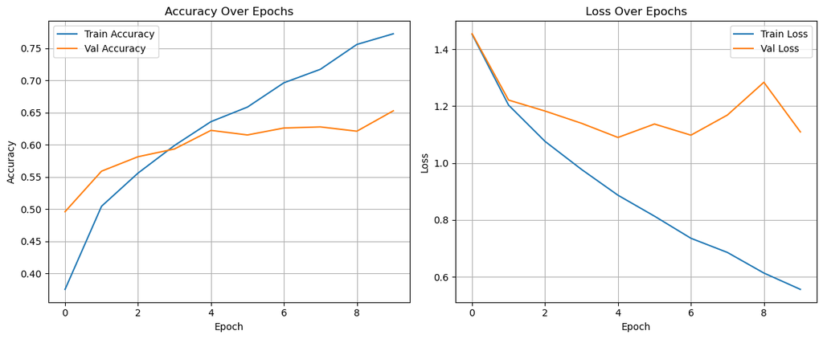

```python
# Plot accuracy and loss over epochs
plt.figure(figsize=(12, 5))

# Accuracy Plot
plt.subplot(1, 2, 1)
plt.plot(history.history['accuracy'], label='Train Accuracy')
plt.plot(history.history['val_accuracy'], label='Val Accuracy')
plt.title('Accuracy Over Epochs')
plt.xlabel('Epoch')
plt.ylabel('Accuracy')
plt.legend()
plt.grid(True)

# Loss Plot
plt.subplot(1, 2, 2)
plt.plot(history.history['loss'], label='Train Loss')
plt.plot(history.history['val_loss'], label='Val Loss')
plt.title('Loss Over Epochs')
plt.xlabel('Epoch')
plt.ylabel('Loss')
plt.legend()
plt.grid(True)

plt.tight_layout()
plt.show()
```

**Observation**

The training accuracy gradually improves and reaches about **76%** by the 10th epoch. The validation accuracy also increases, peaking around **65%**, but doesn’t go much higher after that. This suggests the model is learning well but starts to **overfit** slightly - it gets better on training data than on new data.

Looking at the **loss**, the **training loss consistently goes down**, which is expected as the model learns. However, the **validation loss drops at first**, then starts to **go up and down slightly**, especially after epoch 4. This shows that while the model keeps improving on the training set, it has **trouble improving on the validation set**, likely because it’s starting to **memorize the training data** instead of learning general patterns.

### 2. Evaluate on Validation Set

```python
# Check final performance on the validation set
val_loss, val_acc = model.evaluate(val_generator)
print(f"Validation Accuracy: {val_acc:.2f}")
print(f"Validation Loss: {val_loss:.2f}")
```

```
145/145 ━━━━━━━━━━━━━━━━━━━━ 55s 377ms/step - accuracy: 0.6622 - loss: 1.1077
Validation Accuracy: 0.65
Validation Loss: 1.11
```

**Observation**

*The model achieves a validation accuracy of 65% and a validation loss of 1.11, which matches what we saw in the plot. It confirms that the model has a decent understanding of the images but still makes some mistakes.*

### 3. Confusion Matrix

[output not shown]

[output cut: 90 more lines]

[output not shown]

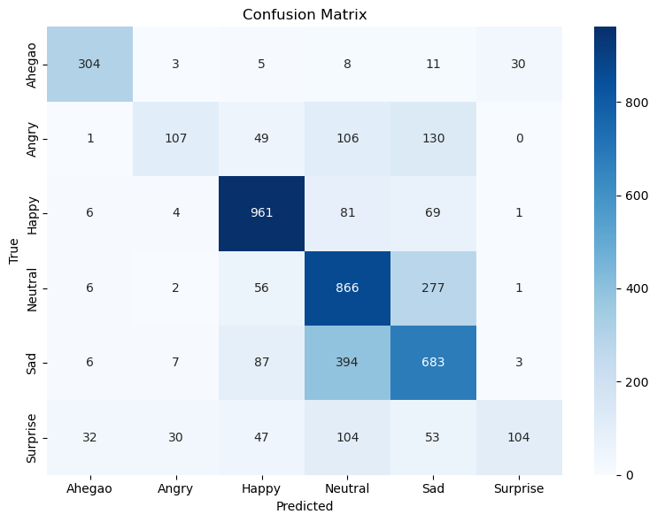

```
              precision    recall  f1-score   support

      Ahegao       0.86      0.84      0.85       361
       Angry       0.70      0.27      0.39       393
       Happy       0.80      0.86      0.83      1122
     Neutral       0.56      0.72      0.63      1208
         Sad       0.56      0.58      0.57      1180
    Surprise       0.75      0.28      0.41       370

    accuracy                           0.65      4634
   macro avg       0.70      0.59      0.61      4634
weighted avg       0.67      0.65      0.64      4634
```

```python
# Import tools for confusion matrix
from sklearn.metrics import confusion_matrix, classification_report
import seaborn as sns

# Get true and predicted labels
y_true = []
y_pred = []

val_generator.reset()
for i in range(len(val_generator)):
    x, y = val_generator[i]
    preds = model.predict(x)
    y_true.extend(np.argmax(y, axis=1))
    y_pred.extend(np.argmax(preds, axis=1))

# Get class names
class_names = list(val_generator.class_indices.keys())

# Confusion matrix Heatmap
cm = confusion_matrix(y_true, y_pred)

plt.figure(figsize=(8, 6))
sns.heatmap(cm, annot=True, fmt='d', xticklabels=class_names, yticklabels=class_names, cmap="Blues")
plt.xlabel('Predicted')
plt.ylabel('True')
plt.title('Confusion Matrix')
plt.tight_layout()
plt.show()

# Classification report
print(classification_report(y_true, y_pred, target_names=class_names))
```

**Observation**

1. Confusion Matrix
   - *The model performed best on the 'Happy' and 'Neutral' classes, with many correct predictions.*
   - *The 'Angry' and 'Surprise' categories were the hardest to classify correctly, with many misclassifications into 'Neutral' and other emotions.*
2. Classification Report Highlights
   - *The model performs best on "Happy" and "Ahegao", with high precision and recall, meaning it predicts them correctly and consistently.*
   - *"Angry" and "Surprise" have low recall, especially "Angry" (0.27), indicating the model often fails to detect them correctly.*
   - *"Neutral" has moderate performance, but is sometimes overpredicted (common for misclassifications).*
   - *Overall, the model is fairly balanced, with reasonable precision and F1-scores, but struggles more on less common or visually confusing emotions like "Surprise" and "Angry".*

### **Show Predictions (Correct vs Incorrect)**

*This step helps us better understand how the model performs on real validation images. By displaying both correct and incorrect predictions, we can visually inspect what the model is doing well and where it struggles.*

```
1/1 ━━━━━━━━━━━━━━━━━━━━ 0s 134ms/step
```

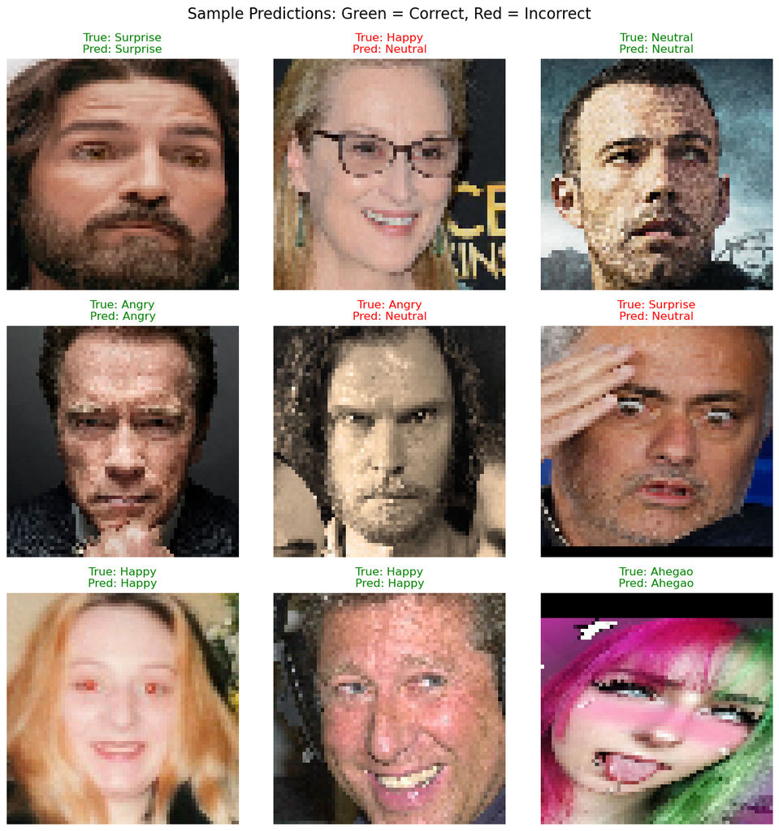

```python
# Get a batch from the validation set
x_val, y_val = next(val_generator)
y_pred = model.predict(x_val)

# Decode one-hot labels to class indices
true_labels = np.argmax(y_val, axis=1)
pred_labels = np.argmax(y_pred, axis=1)
class_names = list(val_generator.class_indices.keys())

# Plot 9 images with predictions
plt.figure(figsize=(12, 12))
for i in range(9):
    plt.subplot(3, 3, i+1)
    plt.imshow(x_val[i])
    true_class = class_names[true_labels[i]]
    pred_class = class_names[pred_labels[i]]
    color = 'green' if true_class == pred_class else 'red'
    plt.title(f"True: {true_class}\nPred: {pred_class}", color=color, fontsize=12)
    plt.axis('off')
plt.tight_layout()
plt.suptitle("Sample Predictions: Green = Correct, Red = Incorrect", fontsize=16, y=1.02)
plt.show()
```

### **Unsupervised Learning with PCA**

*We used PCA (Principal Component Analysis) to reduce the high-dimensional features from our CNN to 2D for visualization. This helps us better understand how the model “sees” and separates different emotions.*

### 1. Rebuild CNN Using the Functional API

*We rebuilt the CNN using the Functional API to better support feature extraction later for PCA.*

```python
from tensorflow.keras.models import Model
from tensorflow.keras.layers import Conv2D, MaxPooling2D, Flatten, Dense, Dropout, Input

# Define input
input_layer = Input(shape=(64, 64, 3))

# Build the CNN layers
x = Conv2D(32, (3, 3), activation='relu')(input_layer)
x = MaxPooling2D(2, 2)(x)

x = Conv2D(64, (3, 3), activation='relu')(x)
x = MaxPooling2D(2, 2)(x)

x = Flatten()(x)
x = Dense(128, activation='relu')(x)         # <-- we’ll extract features from here
x = Dropout(0.5)(x)
output_layer = Dense(6, activation='softmax')(x)

# Now define the full model
model = Model(inputs=input_layer, outputs=output_layer)

# Compile
model.compile(optimizer='adam',
              loss='categorical_crossentropy',
              metrics=['accuracy'])

# Show summary
model.summary()
```

```
Model: "functional_1"
```

```
┏━━━━━━━━━━━━━━━━━━━━━━━━━━━━━━━━━━━━━━┳━━━━━━━━━━━━━━━━━━━━━━━━━━━━━┳━━━━━━━━━━━━━━━━━┓
┃ Layer (type)                         ┃ Output Shape                ┃         Param # ┃
┡━━━━━━━━━━━━━━━━━━━━━━━━━━━━━━━━━━━━━━╇━━━━━━━━━━━━━━━━━━━━━━━━━━━━━╇━━━━━━━━━━━━━━━━━┩
│ input_layer_1 (InputLayer)           │ (None, 64, 64, 3)           │               0 │
├──────────────────────────────────────┼─────────────────────────────┼─────────────────┤
│ conv2d_2 (Conv2D)                    │ (None, 62, 62, 32)          │             896 │
├──────────────────────────────────────┼─────────────────────────────┼─────────────────┤
│ max_pooling2d_2 (MaxPooling2D)       │ (None, 31, 31, 32)          │               0 │
├──────────────────────────────────────┼─────────────────────────────┼─────────────────┤
│ conv2d_3 (Conv2D)                    │ (None, 29, 29, 64)          │          18,496 │
├──────────────────────────────────────┼─────────────────────────────┼─────────────────┤
│ max_pooling2d_3 (MaxPooling2D)       │ (None, 14, 14, 64)          │               0 │
├──────────────────────────────────────┼─────────────────────────────┼─────────────────┤
│ flatten_1 (Flatten)                  │ (None, 12544)               │               0 │
├──────────────────────────────────────┼─────────────────────────────┼─────────────────┤
│ dense_2 (Dense)                      │ (None, 128)                 │       1,605,760 │
├──────────────────────────────────────┼─────────────────────────────┼─────────────────┤
│ dropout_1 (Dropout)                  │ (None, 128)                 │               0 │
├──────────────────────────────────────┼─────────────────────────────┼─────────────────┤
│ dense_3 (Dense)                      │ (None, 6)                   │             774 │
└──────────────────────────────────────┴─────────────────────────────┴─────────────────┘
```

```
 Total params: 1,625,926 (6.20 MB)
```

```
 Trainable params: 1,625,926 (6.20 MB)
```

```
 Non-trainable params: 0 (0.00 B)
```

**Observation**

*The model has a total of ~1.6 million trainable parameters, with the majority coming from the Dense layer (128 units). This shows the model is relatively compact and well-structured for both classification and feature extraction tasks.*

### 2. "Call" the Model with a Real Batch

*This line of code simply runs one batch of images through the CNN model to ensure that the model is working and producing predictions. This also helps "warm up" the model so we can extract feature vectors for PCA in the next step.*

```python
# This is enough to "activate" the model and define input/output
x_sample, _ = next(train_generator)
model.predict(x_sample)
```

```
1/1 ━━━━━━━━━━━━━━━━━━━━ 0s 211ms/step
```

[output not shown]

[output cut: 9 more lines]

[output not shown]

**Observation**

*We successfully generated a prediction array, where each row contains the model’s predicted probabilities for the 6 emotion classes. This confirms the CNN model is active and producing outputs, which we’ll use next for dimensionality reduction.*

### 3. Create the Feature Extractor

*This will help capture meaningful patterns from images without actually predicting the class.*

```python
# Extract features from the layer before Dropout (Dense layer with 128 units)
feature_extractor = Model(inputs=model.input, outputs=model.layers[-3].output)
```

### 4. Get Features from Validation Images

```python
val_generator.reset()
x_batch, y_batch = next(val_generator)  # Get a batch of validation images

# Extract features
features = feature_extractor.predict(x_batch)

# Reshape features for PCA
features_flat = features.reshape(features.shape[0], -1)
print("Feature shape for PCA:", features_flat.shape)
```

```
1/1 ━━━━━━━━━━━━━━━━━━━━ 0s 169ms/step
Feature shape for PCA: (32, 128)
```

**Observation**

*We successfully extracted dense features from the CNN model. These feature vectors can now be used for unsupervised learning tasks like PCA or clustering to explore patterns in the data visually.*

*The shape (32, 128) means we got 32 feature vectors, each with 128 values (one per image).*

### 5. Apply PCA and Visualize

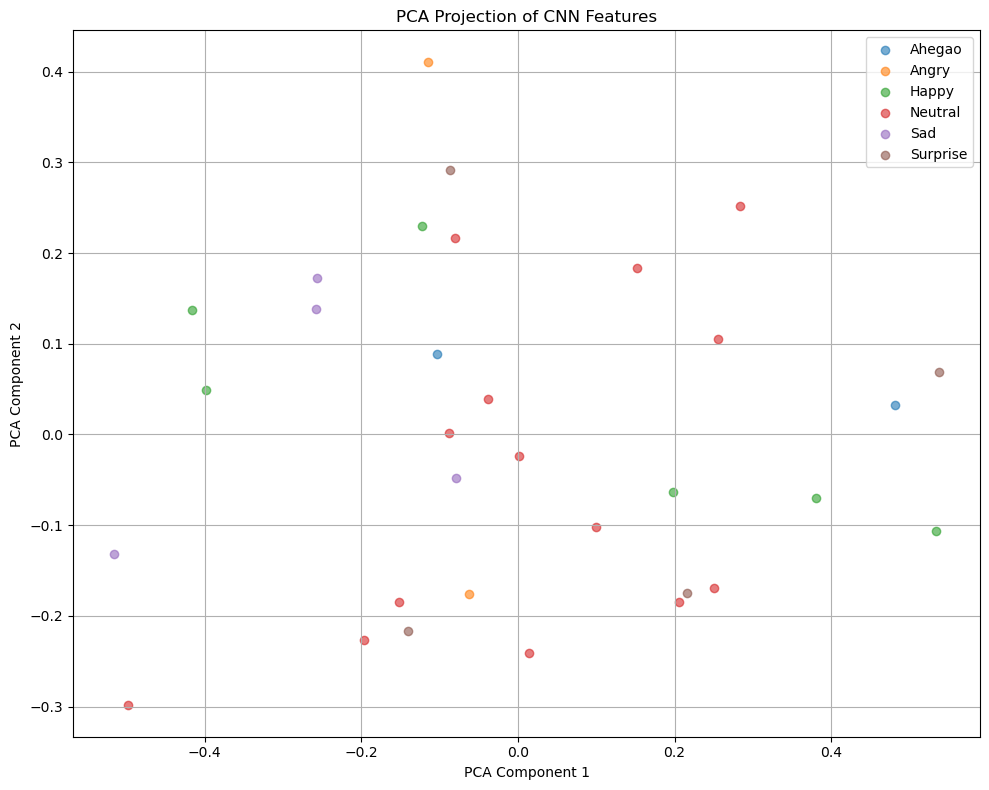

```python
# Import PCA and visualization libraries
from sklearn.decomposition import PCA
import matplotlib.pyplot as plt
import numpy as np

# # Reduce the feature vectors to 2 principal components (for 2D visualization)
pca = PCA(n_components=2)
pca_result = pca.fit_transform(features_flat)

# Prepare true labels and class names
true_labels = np.argmax(y_batch, axis=1)
class_names = list(val_generator.class_indices.keys())

# Plot PCA results
plt.figure(figsize=(10, 8))
for i, label in enumerate(np.unique(true_labels)):
    indices = true_labels == label    # Find all samples with the current label
    plt.scatter(pca_result[indices, 0], pca_result[indices, 1], label=class_names[label], alpha=0.6)

# Add plot labels and legend
plt.title("PCA Projection of CNN Features")
plt.xlabel("PCA Component 1")
plt.ylabel("PCA Component 2")
plt.legend()
plt.grid(True)
plt.tight_layout()
plt.show()
```

### **Logistic Regression on CNN Features**

*In this section, we compare the deep learning approach with a classical machine learning model by applying Logistic Regression to features extracted from our CNN. By using these high-level, deep features as input, we evaluate how well a shallow classifier performs in predicting emotion classes, providing a useful baseline for comparison with our CNN model.*

```python
from sklearn.linear_model import LogisticRegression
from sklearn.metrics import accuracy_score, classification_report

# STEP 1: Prepare the data
# Use the same features and labels from your PCA block
X = features_flat  # extracted CNN features, already flattened
y = np.argmax(y_batch, axis=1)  # Convert one-hot to integer labels

# STEP 2: Fit Logistic Regression
# Solver 'lbfgs' works well for small-medium datasets
log_model = LogisticRegression(max_iter=1000)
log_model.fit(X, y)

# STEP 3: Predict and evaluate
y_pred_lr = log_model.predict(X)

# Accuracy
accuracy = accuracy_score(y, y_pred_lr)
print(f"Logistic Regression Accuracy on PCA Features: {accuracy:.2f}")

# Detailed report
print(classification_report(y, y_pred_lr, target_names=class_names, zero_division=0))
```

```
Logistic Regression Accuracy on PCA Features: 0.44
              precision    recall  f1-score   support

      Ahegao       0.00      0.00      0.00         2
       Angry       0.00      0.00      0.00         2
       Happy       0.00      0.00      0.00         6
     Neutral       0.44      1.00      0.61        14
         Sad       0.00      0.00      0.00         4
    Surprise       0.00      0.00      0.00         4

    accuracy                           0.44        32
   macro avg       0.07      0.17      0.10        32
weighted avg       0.19      0.44      0.27        32
```

### **Conclusion**

*In this project, we built a Convolutional Neural Network (CNN) to classify facial emotions into six categories. The model reached 76% training accuracy and 65% validation accuracy. While it learned useful patterns, the validation loss stopped improving and slightly increased, showing signs of overfitting. The confusion matrix and metrics showed good results for "Happy" and "Neutral," but emotions like "Angry" and "Surprise" were harder to predict.*